# SQ 017

## Shared Qs (017)

#### Question

1. A [geometric sequence](https://en.wikipedia.org/wiki/Geometric_progression) has a common **ratio** between subsequent terms (*remember an arithmetic progression has a common **difference** between terms*).

   Let $g_{n}$ represent the $n$th value in a geometric progression with the following [recursive](https://en.wikipedia.org/wiki/Recurrence_relation) definition:
   $$g_1 = 7$$
   $$g_{[n+1]} = g_{[n]}\cdot 2$$
   where $n$ is any [natural number](https://en.wikipedia.org/wiki/Natural_number). Using this recursive definition can produce the next few values.
   $$g_2 ~=~ g_1 \cdot 2 ~=~ 7\cdot2 ~=~ 14$$
   $$g_3 ~=~ g_2 \cdot 2 ~=~ 14\cdot2 ~=~ 28$$
   $$g_4 ~=~ g_3 \cdot 2 ~=~ 28\cdot2 ~=~ 56$$

   In general, if a geometric progression has an initial term $g_1$ and a common ratio $r$, we can write an explicit formula to find the $n$th value.

   $$g_n = g_1r^{n-1}$$
   - Evaluate $g_{9}$

#### Solution

#### Question

2. A [geometric sequence](https://en.wikipedia.org/wiki/Geometric_progression) has a common **ratio** between subsequent terms (*remember an arithmetic progression has a common **difference** between terms*).

   Let $g_{n}$ represent the $n$th value in a geometric progression with the following [recursive](https://en.wikipedia.org/wiki/Recurrence_relation) definition:
   $$g_1 = 6$$
   $$g_{[n+1]} = g_{[n]}\cdot 4$$
   where $n$ is any [natural number](https://en.wikipedia.org/wiki/Natural_number). Using this recursive definition can produce the next few values.
   $$g_2 ~=~ g_1 \cdot 4 ~=~ 6\cdot4 ~=~ 24$$
   $$g_3 ~=~ g_2 \cdot 4 ~=~ 24\cdot4 ~=~ 96$$
   $$g_4 ~=~ g_3 \cdot 4 ~=~ 96\cdot4 ~=~ 384$$

   In general, if a geometric progression has an initial term $g_1$ and a common ratio $r$, we can write an explicit formula to find the $n$th value.

   $$g_n = g_1r^{n-1}$$
   - Evaluate $g_{9}$

#### Solution

#### Question

3. A [geometric sequence](https://en.wikipedia.org/wiki/Geometric_progression) has a common **ratio** between subsequent terms (*remember an arithmetic progression has a common **difference** between terms*).

   Let $g_{n}$ represent the $n$th value in a geometric progression with the following [recursive](https://en.wikipedia.org/wiki/Recurrence_relation) definition:
   $$g_1 = 4$$
   $$g_{[n+1]} = g_{[n]}\cdot 5$$
   where $n$ is any [natural number](https://en.wikipedia.org/wiki/Natural_number). Using this recursive definition can produce the next few values.
   $$g_2 ~=~ g_1 \cdot 5 ~=~ 4\cdot5 ~=~ 20$$
   $$g_3 ~=~ g_2 \cdot 5 ~=~ 20\cdot5 ~=~ 100$$
   $$g_4 ~=~ g_3 \cdot 5 ~=~ 100\cdot5 ~=~ 500$$

   In general, if a geometric progression has an initial term $g_1$ and a common ratio $r$, we can write an explicit formula to find the $n$th value.

   $$g_n = g_1r^{n-1}$$
   - Evaluate $g_{9}$

#### Solution

#### Question

4. A [geometric sequence](https://en.wikipedia.org/wiki/Geometric_progression) has a common **ratio** between subsequent terms (*remember an arithmetic progression has a common **difference** between terms*).

   Let $g_{n}$ represent the $n$th value in a geometric progression with the following [recursive](https://en.wikipedia.org/wiki/Recurrence_relation) definition:
   $$g_1 = 7$$
   $$g_{[n+1]} = g_{[n]}\cdot 4$$
   where $n$ is any [natural number](https://en.wikipedia.org/wiki/Natural_number). Using this recursive definition can produce the next few values.
   $$g_2 ~=~ g_1 \cdot 4 ~=~ 7\cdot4 ~=~ 28$$
   $$g_3 ~=~ g_2 \cdot 4 ~=~ 28\cdot4 ~=~ 112$$
   $$g_4 ~=~ g_3 \cdot 4 ~=~ 112\cdot4 ~=~ 448$$

   In general, if a geometric progression has an initial term $g_1$ and a common ratio $r$, we can write an explicit formula to find the $n$th value.

   $$g_n = g_1r^{n-1}$$
   - Evaluate $g_{9}$

#### Solution

#### Question

5. A [geometric sequence](https://en.wikipedia.org/wiki/Geometric_progression) has a common **ratio** between subsequent terms (*remember an arithmetic progression has a common **difference** between terms*).

   Let $g_{n}$ represent the $n$th value in a geometric progression with the following [recursive](https://en.wikipedia.org/wiki/Recurrence_relation) definition:
   $$g_1 = 3$$
   $$g_{[n+1]} = g_{[n]}\cdot 2$$
   where $n$ is any [natural number](https://en.wikipedia.org/wiki/Natural_number). Using this recursive definition can produce the next few values.
   $$g_2 ~=~ g_1 \cdot 2 ~=~ 3\cdot2 ~=~ 6$$
   $$g_3 ~=~ g_2 \cdot 2 ~=~ 6\cdot2 ~=~ 12$$
   $$g_4 ~=~ g_3 \cdot 2 ~=~ 12\cdot2 ~=~ 24$$

   In general, if a geometric progression has an initial term $g_1$ and a common ratio $r$, we can write an explicit formula to find the $n$th value.

   $$g_n = g_1r^{n-1}$$
   - Evaluate $g_{7}$

#### Solution

#### Question

6. A [geometric sequence](https://en.wikipedia.org/wiki/Geometric_progression) has a common **ratio** between subsequent terms (*remember an arithmetic progression has a common **difference** between terms*).

   Let $g_{n}$ represent the $n$th value in a geometric progression with the following [recursive](https://en.wikipedia.org/wiki/Recurrence_relation) definition:
   $$g_1 = 6$$
   $$g_{[n+1]} = g_{[n]}\cdot 5$$
   where $n$ is any [natural number](https://en.wikipedia.org/wiki/Natural_number). Using this recursive definition can produce the next few values.
   $$g_2 ~=~ g_1 \cdot 5 ~=~ 6\cdot5 ~=~ 30$$
   $$g_3 ~=~ g_2 \cdot 5 ~=~ 30\cdot5 ~=~ 150$$
   $$g_4 ~=~ g_3 \cdot 5 ~=~ 150\cdot5 ~=~ 750$$

   In general, if a geometric progression has an initial term $g_1$ and a common ratio $r$, we can write an explicit formula to find the $n$th value.

   $$g_n = g_1r^{n-1}$$
   - Evaluate $g_{8}$

#### Solution

#### Question

7. A [geometric sequence](https://en.wikipedia.org/wiki/Geometric_progression) has a common **ratio** between subsequent terms (*remember an arithmetic progression has a common **difference** between terms*).

   Let $g_{n}$ represent the $n$th value in a geometric progression with the following [recursive](https://en.wikipedia.org/wiki/Recurrence_relation) definition:
   $$g_1 = 2$$
   $$g_{[n+1]} = g_{[n]}\cdot 5$$
   where $n$ is any [natural number](https://en.wikipedia.org/wiki/Natural_number). Using this recursive definition can produce the next few values.
   $$g_2 ~=~ g_1 \cdot 5 ~=~ 2\cdot5 ~=~ 10$$
   $$g_3 ~=~ g_2 \cdot 5 ~=~ 10\cdot5 ~=~ 50$$
   $$g_4 ~=~ g_3 \cdot 5 ~=~ 50\cdot5 ~=~ 250$$

   In general, if a geometric progression has an initial term $g_1$ and a common ratio $r$, we can write an explicit formula to find the $n$th value.

   $$g_n = g_1r^{n-1}$$
   - Evaluate $g_{9}$

#### Solution

#### Question

8. A [geometric sequence](https://en.wikipedia.org/wiki/Geometric_progression) has a common **ratio** between subsequent terms (*remember an arithmetic progression has a common **difference** between terms*).

   Let $g_{n}$ represent the $n$th value in a geometric progression with the following [recursive](https://en.wikipedia.org/wiki/Recurrence_relation) definition:
   $$g_1 = 4$$
   $$g_{[n+1]} = g_{[n]}\cdot 5$$
   where $n$ is any [natural number](https://en.wikipedia.org/wiki/Natural_number). Using this recursive definition can produce the next few values.
   $$g_2 ~=~ g_1 \cdot 5 ~=~ 4\cdot5 ~=~ 20$$
   $$g_3 ~=~ g_2 \cdot 5 ~=~ 20\cdot5 ~=~ 100$$
   $$g_4 ~=~ g_3 \cdot 5 ~=~ 100\cdot5 ~=~ 500$$

   In general, if a geometric progression has an initial term $g_1$ and a common ratio $r$, we can write an explicit formula to find the $n$th value.

   $$g_n = g_1r^{n-1}$$
   - Evaluate $g_{7}$

#### Solution

#### Question

9. A [geometric sequence](https://en.wikipedia.org/wiki/Geometric_progression) has a common **ratio** between subsequent terms (*remember an arithmetic progression has a common **difference** between terms*).

   Let $g_{n}$ represent the $n$th value in a geometric progression with the following [recursive](https://en.wikipedia.org/wiki/Recurrence_relation) definition:
   $$g_1 = 6$$
   $$g_{[n+1]} = g_{[n]}\cdot 2$$
   where $n$ is any [natural number](https://en.wikipedia.org/wiki/Natural_number). Using this recursive definition can produce the next few values.
   $$g_2 ~=~ g_1 \cdot 2 ~=~ 6\cdot2 ~=~ 12$$
   $$g_3 ~=~ g_2 \cdot 2 ~=~ 12\cdot2 ~=~ 24$$
   $$g_4 ~=~ g_3 \cdot 2 ~=~ 24\cdot2 ~=~ 48$$

   In general, if a geometric progression has an initial term $g_1$ and a common ratio $r$, we can write an explicit formula to find the $n$th value.

   $$g_n = g_1r^{n-1}$$
   - Evaluate $g_{8}$

#### Solution

#### Question

10. A [geometric sequence](https://en.wikipedia.org/wiki/Geometric_progression) has a common **ratio** between subsequent terms (*remember an arithmetic progression has a common **difference** between terms*).

    Let $g_{n}$ represent the $n$th value in a geometric progression with the following [recursive](https://en.wikipedia.org/wiki/Recurrence_relation) definition:
    $$g_1 = 6$$
    $$g_{[n+1]} = g_{[n]}\cdot 4$$
    where $n$ is any [natural number](https://en.wikipedia.org/wiki/Natural_number). Using this recursive definition can produce the next few values.
    $$g_2 ~=~ g_1 \cdot 4 ~=~ 6\cdot4 ~=~ 24$$
    $$g_3 ~=~ g_2 \cdot 4 ~=~ 24\cdot4 ~=~ 96$$
    $$g_4 ~=~ g_3 \cdot 4 ~=~ 96\cdot4 ~=~ 384$$

    In general, if a geometric progression has an initial term $g_1$ and a common ratio $r$, we can write an explicit formula to find the $n$th value.

    $$g_n = g_1r^{n-1}$$
    - Evaluate $g_{8}$

#### Solution

#### Question

11. In music, an [equal temperament](https://en.wikipedia.org/wiki/Equal_temperament) implies the available [fundamental frequencies](https://en.wikipedia.org/wiki/Fundamental_frequency) follow a geometric progression. Imagine a [keyboard instrument](https://en.wikipedia.org/wiki/Keyboard_instrument) for [31 EDO](https://en.wikipedia.org/wiki/31_equal_temperament). That means there are 31 frequencies per octave, and the ratio between neighboring frequencies is $2^{1/31} \approx 1.0226114$. That instrument acts as a function that maps [key number ($k$) to frequency ($f$)](https://en.wikipedia.org/wiki/Piano_key_frequencies).

    Let’s assume a [concert pitch](https://en.wikipedia.org/wiki/Concert_pitch) of 440 Hz is assigned to the key number 123, so we can calculate the frequency from any key number using the following [exponential function](https://en.wikipedia.org/wiki/Exponential_function).

    $$f = 440 \cdot 2^{(k-123)/31}$$

    What is the frequency, in [Hz](https://en.wikipedia.org/wiki/Hertz), of key number $k=$ 99? *The tolerance is $\pm 1$ Hz.*

#### Solution

#### Question

12. In music, an [equal temperament](https://en.wikipedia.org/wiki/Equal_temperament) implies the available [fundamental frequencies](https://en.wikipedia.org/wiki/Fundamental_frequency) follow a geometric progression. Imagine a [keyboard instrument](https://en.wikipedia.org/wiki/Keyboard_instrument) for [72 EDO](https://en.wikipedia.org/wiki/72_equal_temperament). That means there are 72 frequencies per octave, and the ratio between neighboring frequencies is $2^{1/72} \approx 1.0096735$. That instrument acts as a function that maps [key number ($k$) to frequency ($f$)](https://en.wikipedia.org/wiki/Piano_key_frequencies).

    Let’s assume a [concert pitch](https://en.wikipedia.org/wiki/Concert_pitch) of 440 Hz is assigned to the key number 248, so we can calculate the frequency from any key number using the following [exponential function](https://en.wikipedia.org/wiki/Exponential_function).

    $$f = 440 \cdot 2^{(k-248)/72}$$

    What is the frequency, in [Hz](https://en.wikipedia.org/wiki/Hertz), of key number $k=$ 243? *The tolerance is $\pm 1$ Hz.*

#### Solution

#### Question

13. In music, an [equal temperament](https://en.wikipedia.org/wiki/Equal_temperament) implies the available [fundamental frequencies](https://en.wikipedia.org/wiki/Fundamental_frequency) follow a geometric progression. Imagine a [keyboard instrument](https://en.wikipedia.org/wiki/Keyboard_instrument) for [41 EDO](https://en.wikipedia.org/wiki/41_equal_temperament). That means there are 41 frequencies per octave, and the ratio between neighboring frequencies is $2^{1/41} \approx 1.0170497$. That instrument acts as a function that maps [key number ($k$) to frequency ($f$)](https://en.wikipedia.org/wiki/Piano_key_frequencies).

    Let’s assume a [concert pitch](https://en.wikipedia.org/wiki/Concert_pitch) of 440 Hz is assigned to the key number 160, so we can calculate the frequency from any key number using the following [exponential function](https://en.wikipedia.org/wiki/Exponential_function).

    $$f = 440 \cdot 2^{(k-160)/41}$$

    What is the frequency, in [Hz](https://en.wikipedia.org/wiki/Hertz), of key number $k=$ 122? *The tolerance is $\pm 1$ Hz.*

#### Solution

#### Question

14. In music, an [equal temperament](https://en.wikipedia.org/wiki/Equal_temperament) implies the available [fundamental frequencies](https://en.wikipedia.org/wiki/Fundamental_frequency) follow a geometric progression. Imagine a [keyboard instrument](https://en.wikipedia.org/wiki/Keyboard_instrument) for [22 EDO](https://en.wikipedia.org/wiki/22_equal_temperament). That means there are 22 frequencies per octave, and the ratio between neighboring frequencies is $2^{1/22} \approx 1.0320083$. That instrument acts as a function that maps [key number ($k$) to frequency ($f$)](https://en.wikipedia.org/wiki/Piano_key_frequencies).

    Let’s assume a [concert pitch](https://en.wikipedia.org/wiki/Concert_pitch) of 440 Hz is assigned to the key number 85, so we can calculate the frequency from any key number using the following [exponential function](https://en.wikipedia.org/wiki/Exponential_function).

    $$f = 440 \cdot 2^{(k-85)/22}$$

    What is the frequency, in [Hz](https://en.wikipedia.org/wiki/Hertz), of key number $k=$ 70? *The tolerance is $\pm 1$ Hz.*

#### Solution

#### Question

15. In music, an [equal temperament](https://en.wikipedia.org/wiki/Equal_temperament) implies the available [fundamental frequencies](https://en.wikipedia.org/wiki/Fundamental_frequency) follow a geometric progression. Imagine a [keyboard instrument](https://en.wikipedia.org/wiki/Keyboard_instrument) for [24 EDO](https://en.wikipedia.org/wiki/Quarter_tone). That means there are 24 frequencies per octave, and the ratio between neighboring frequencies is $2^{1/24} \approx 1.0293022$. That instrument acts as a function that maps [key number ($k$) to frequency ($f$)](https://en.wikipedia.org/wiki/Piano_key_frequencies).

    Let’s assume a [concert pitch](https://en.wikipedia.org/wiki/Concert_pitch) of 440 Hz is assigned to the key number 110, so we can calculate the frequency from any key number using the following [exponential function](https://en.wikipedia.org/wiki/Exponential_function).

    $$f = 440 \cdot 2^{(k-110)/24}$$

    What is the frequency, in [Hz](https://en.wikipedia.org/wiki/Hertz), of key number $k=$ 95? *The tolerance is $\pm 1$ Hz.*

#### Solution

#### Question

16. In music, an [equal temperament](https://en.wikipedia.org/wiki/Equal_temperament) implies the available [fundamental frequencies](https://en.wikipedia.org/wiki/Fundamental_frequency) follow a geometric progression. Imagine a [keyboard instrument](https://en.wikipedia.org/wiki/Keyboard_instrument) for [96 EDO](https://en.wikipedia.org/wiki/96_equal_temperament). That means there are 96 frequencies per octave, and the ratio between neighboring frequencies is $2^{1/96} \approx 1.0072464$. That instrument acts as a function that maps [key number ($k$) to frequency ($f$)](https://en.wikipedia.org/wiki/Piano_key_frequencies).

    Let’s assume a [concert pitch](https://en.wikipedia.org/wiki/Concert_pitch) of 440 Hz is assigned to the key number 354, so we can calculate the frequency from any key number using the following [exponential function](https://en.wikipedia.org/wiki/Exponential_function).

    $$f = 440 \cdot 2^{(k-354)/96}$$

    What is the frequency, in [Hz](https://en.wikipedia.org/wiki/Hertz), of key number $k=$ 198? *The tolerance is $\pm 1$ Hz.*

#### Solution

#### Question

17. In music, an [equal temperament](https://en.wikipedia.org/wiki/Equal_temperament) implies the available [fundamental frequencies](https://en.wikipedia.org/wiki/Fundamental_frequency) follow a geometric progression. Imagine a [keyboard instrument](https://en.wikipedia.org/wiki/Keyboard_instrument) for [31 EDO](https://en.wikipedia.org/wiki/31_equal_temperament). That means there are 31 frequencies per octave, and the ratio between neighboring frequencies is $2^{1/31} \approx 1.0226114$. That instrument acts as a function that maps [key number ($k$) to frequency ($f$)](https://en.wikipedia.org/wiki/Piano_key_frequencies).

    Let’s assume a [concert pitch](https://en.wikipedia.org/wiki/Concert_pitch) of 440 Hz is assigned to the key number 127, so we can calculate the frequency from any key number using the following [exponential function](https://en.wikipedia.org/wiki/Exponential_function).

    $$f = 440 \cdot 2^{(k-127)/31}$$

    What is the frequency, in [Hz](https://en.wikipedia.org/wiki/Hertz), of key number $k=$ 90? *The tolerance is $\pm 1$ Hz.*

#### Solution

#### Question

18. In music, an [equal temperament](https://en.wikipedia.org/wiki/Equal_temperament) implies the available [fundamental frequencies](https://en.wikipedia.org/wiki/Fundamental_frequency) follow a geometric progression. Imagine a [keyboard instrument](https://en.wikipedia.org/wiki/Keyboard_instrument) for [24 EDO](https://en.wikipedia.org/wiki/Quarter_tone). That means there are 24 frequencies per octave, and the ratio between neighboring frequencies is $2^{1/24} \approx 1.0293022$. That instrument acts as a function that maps [key number ($k$) to frequency ($f$)](https://en.wikipedia.org/wiki/Piano_key_frequencies).

    Let’s assume a [concert pitch](https://en.wikipedia.org/wiki/Concert_pitch) of 440 Hz is assigned to the key number 92, so we can calculate the frequency from any key number using the following [exponential function](https://en.wikipedia.org/wiki/Exponential_function).

    $$f = 440 \cdot 2^{(k-92)/24}$$

    What is the frequency, in [Hz](https://en.wikipedia.org/wiki/Hertz), of key number $k=$ 76? *The tolerance is $\pm 1$ Hz.*

#### Solution

#### Question

19. In music, an [equal temperament](https://en.wikipedia.org/wiki/Equal_temperament) implies the available [fundamental frequencies](https://en.wikipedia.org/wiki/Fundamental_frequency) follow a geometric progression. Imagine a [keyboard instrument](https://en.wikipedia.org/wiki/Keyboard_instrument) for [53 EDO](https://en.wikipedia.org/wiki/53_equal_temperament). That means there are 53 frequencies per octave, and the ratio between neighboring frequencies is $2^{1/53} \approx 1.0131641$. That instrument acts as a function that maps [key number ($k$) to frequency ($f$)](https://en.wikipedia.org/wiki/Piano_key_frequencies).

    Let’s assume a [concert pitch](https://en.wikipedia.org/wiki/Concert_pitch) of 440 Hz is assigned to the key number 183, so we can calculate the frequency from any key number using the following [exponential function](https://en.wikipedia.org/wiki/Exponential_function).

    $$f = 440 \cdot 2^{(k-183)/53}$$

    What is the frequency, in [Hz](https://en.wikipedia.org/wiki/Hertz), of key number $k=$ 102? *The tolerance is $\pm 1$ Hz.*

#### Solution

#### Question

20. In music, an [equal temperament](https://en.wikipedia.org/wiki/Equal_temperament) implies the available [fundamental frequencies](https://en.wikipedia.org/wiki/Fundamental_frequency) follow a geometric progression. Imagine a [keyboard instrument](https://en.wikipedia.org/wiki/Keyboard_instrument) for [96 EDO](https://en.wikipedia.org/wiki/96_equal_temperament). That means there are 96 frequencies per octave, and the ratio between neighboring frequencies is $2^{1/96} \approx 1.0072464$. That instrument acts as a function that maps [key number ($k$) to frequency ($f$)](https://en.wikipedia.org/wiki/Piano_key_frequencies).

    Let’s assume a [concert pitch](https://en.wikipedia.org/wiki/Concert_pitch) of 440 Hz is assigned to the key number 289, so we can calculate the frequency from any key number using the following [exponential function](https://en.wikipedia.org/wiki/Exponential_function).

    $$f = 440 \cdot 2^{(k-289)/96}$$

    What is the frequency, in [Hz](https://en.wikipedia.org/wiki/Hertz), of key number $k=$ 321? *The tolerance is $\pm 1$ Hz.*

#### Solution

#### Question

21. In music, an [equal temperament](https://en.wikipedia.org/wiki/Equal_temperament) implies the available [fundamental frequencies](https://en.wikipedia.org/wiki/Fundamental_frequency) follow a geometric progression. Imagine a [keyboard instrument](https://en.wikipedia.org/wiki/Keyboard_instrument) for [17 EDO](https://en.wikipedia.org/wiki/17_equal_temperament). That means there are 17 frequencies per octave, and the ratio between neighboring frequencies is $2^{1/17} \approx 1.041616$. That instrument acts as a function that maps [key number ($k$) to frequency ($f$)](https://en.wikipedia.org/wiki/Piano_key_frequencies).

    Let’s assume a [concert pitch](https://en.wikipedia.org/wiki/Concert_pitch) of 440 Hz is assigned to the key number 77, so we can calculate the frequency from any key number using the following [exponential function](https://en.wikipedia.org/wiki/Exponential_function).

    $$f = 440 \cdot 2^{(k-77)/17}$$

    The inverse of exponentiation is the [logarithm](https://en.wikipedia.org/wiki/Logarithm). This allows us to create a formula to calculate the key number from the frequency.

    $$k = 17 \log_2\left(\frac{f}{440}\right)+77$$

    What key number produces a frequency of $f=269.7496655$ Hz? (Please round to nearest integer.)

#### Solution

#### Question

22. In music, an [equal temperament](https://en.wikipedia.org/wiki/Equal_temperament) implies the available [fundamental frequencies](https://en.wikipedia.org/wiki/Fundamental_frequency) follow a geometric progression. Imagine a [keyboard instrument](https://en.wikipedia.org/wiki/Keyboard_instrument) for [12 EDO](https://en.wikipedia.org/wiki/12_equal_temperament). That means there are 12 frequencies per octave, and the ratio between neighboring frequencies is $2^{1/12} \approx 1.0594631$. That instrument acts as a function that maps [key number ($k$) to frequency ($f$)](https://en.wikipedia.org/wiki/Piano_key_frequencies).

    Let’s assume a [concert pitch](https://en.wikipedia.org/wiki/Concert_pitch) of 440 Hz is assigned to the key number 43, so we can calculate the frequency from any key number using the following [exponential function](https://en.wikipedia.org/wiki/Exponential_function).

    $$f = 440 \cdot 2^{(k-43)/12}$$

    The inverse of exponentiation is the [logarithm](https://en.wikipedia.org/wiki/Logarithm). This allows us to create a formula to calculate the key number from the frequency.

    $$k = 12 \log_2\left(\frac{f}{440}\right)+43$$

    What key number produces a frequency of $f=311.1269837$ Hz? (Please round to nearest integer.)

#### Solution

#### Question

23. In music, an [equal temperament](https://en.wikipedia.org/wiki/Equal_temperament) implies the available [fundamental frequencies](https://en.wikipedia.org/wiki/Fundamental_frequency) follow a geometric progression. Imagine a [keyboard instrument](https://en.wikipedia.org/wiki/Keyboard_instrument) for [15 EDO](https://en.wikipedia.org/wiki/15_equal_temperament). That means there are 15 frequencies per octave, and the ratio between neighboring frequencies is $2^{1/15} \approx 1.0472941$. That instrument acts as a function that maps [key number ($k$) to frequency ($f$)](https://en.wikipedia.org/wiki/Piano_key_frequencies).

    Let’s assume a [concert pitch](https://en.wikipedia.org/wiki/Concert_pitch) of 440 Hz is assigned to the key number 61, so we can calculate the frequency from any key number using the following [exponential function](https://en.wikipedia.org/wiki/Exponential_function).

    $$f = 440 \cdot 2^{(k-61)/15}$$

    The inverse of exponentiation is the [logarithm](https://en.wikipedia.org/wiki/Logarithm). This allows us to create a formula to calculate the key number from the frequency.

    $$k = 15 \log_2\left(\frac{f}{440}\right)+61$$

    What key number produces a frequency of $f=1058.6620318$ Hz? (Please round to nearest integer.)

#### Solution

#### Question

24. In music, an [equal temperament](https://en.wikipedia.org/wiki/Equal_temperament) implies the available [fundamental frequencies](https://en.wikipedia.org/wiki/Fundamental_frequency) follow a geometric progression. Imagine a [keyboard instrument](https://en.wikipedia.org/wiki/Keyboard_instrument) for [96 EDO](https://en.wikipedia.org/wiki/96_equal_temperament). That means there are 96 frequencies per octave, and the ratio between neighboring frequencies is $2^{1/96} \approx 1.0072464$. That instrument acts as a function that maps [key number ($k$) to frequency ($f$)](https://en.wikipedia.org/wiki/Piano_key_frequencies).

    Let’s assume a [concert pitch](https://en.wikipedia.org/wiki/Concert_pitch) of 440 Hz is assigned to the key number 329, so we can calculate the frequency from any key number using the following [exponential function](https://en.wikipedia.org/wiki/Exponential_function).

    $$f = 440 \cdot 2^{(k-329)/96}$$

    The inverse of exponentiation is the [logarithm](https://en.wikipedia.org/wiki/Logarithm). This allows us to create a formula to calculate the key number from the frequency.

    $$k = 96 \log_2\left(\frac{f}{440}\right)+329$$

    What key number produces a frequency of $f=608.9203481$ Hz? (Please round to nearest integer.)

#### Solution

#### Question

25. In music, an [equal temperament](https://en.wikipedia.org/wiki/Equal_temperament) implies the available [fundamental frequencies](https://en.wikipedia.org/wiki/Fundamental_frequency) follow a geometric progression. Imagine a [keyboard instrument](https://en.wikipedia.org/wiki/Keyboard_instrument) for [72 EDO](https://en.wikipedia.org/wiki/72_equal_temperament). That means there are 72 frequencies per octave, and the ratio between neighboring frequencies is $2^{1/72} \approx 1.0096735$. That instrument acts as a function that maps [key number ($k$) to frequency ($f$)](https://en.wikipedia.org/wiki/Piano_key_frequencies).

    Let’s assume a [concert pitch](https://en.wikipedia.org/wiki/Concert_pitch) of 440 Hz is assigned to the key number 268, so we can calculate the frequency from any key number using the following [exponential function](https://en.wikipedia.org/wiki/Exponential_function).

    $$f = 440 \cdot 2^{(k-268)/72}$$

    The inverse of exponentiation is the [logarithm](https://en.wikipedia.org/wiki/Logarithm). This allows us to create a formula to calculate the key number from the frequency.

    $$k = 72 \log_2\left(\frac{f}{440}\right)+268$$

    What key number produces a frequency of $f=776.479571$ Hz? (Please round to nearest integer.)

#### Solution

#### Question

26. In music, an [equal temperament](https://en.wikipedia.org/wiki/Equal_temperament) implies the available [fundamental frequencies](https://en.wikipedia.org/wiki/Fundamental_frequency) follow a geometric progression. Imagine a [keyboard instrument](https://en.wikipedia.org/wiki/Keyboard_instrument) for [19 EDO](https://en.wikipedia.org/wiki/19_equal_temperament). That means there are 19 frequencies per octave, and the ratio between neighboring frequencies is $2^{1/19} \approx 1.037155$. That instrument acts as a function that maps [key number ($k$) to frequency ($f$)](https://en.wikipedia.org/wiki/Piano_key_frequencies).

    Let’s assume a [concert pitch](https://en.wikipedia.org/wiki/Concert_pitch) of 440 Hz is assigned to the key number 58, so we can calculate the frequency from any key number using the following [exponential function](https://en.wikipedia.org/wiki/Exponential_function).

    $$f = 440 \cdot 2^{(k-58)/19}$$

    The inverse of exponentiation is the [logarithm](https://en.wikipedia.org/wiki/Logarithm). This allows us to create a formula to calculate the key number from the frequency.

    $$k = 19 \log_2\left(\frac{f}{440}\right)+58$$

    What key number produces a frequency of $f=707.0018794$ Hz? (Please round to nearest integer.)

#### Solution

#### Question

27. In music, an [equal temperament](https://en.wikipedia.org/wiki/Equal_temperament) implies the available [fundamental frequencies](https://en.wikipedia.org/wiki/Fundamental_frequency) follow a geometric progression. Imagine a [keyboard instrument](https://en.wikipedia.org/wiki/Keyboard_instrument) for [22 EDO](https://en.wikipedia.org/wiki/22_equal_temperament). That means there are 22 frequencies per octave, and the ratio between neighboring frequencies is $2^{1/22} \approx 1.0320083$. That instrument acts as a function that maps [key number ($k$) to frequency ($f$)](https://en.wikipedia.org/wiki/Piano_key_frequencies).

    Let’s assume a [concert pitch](https://en.wikipedia.org/wiki/Concert_pitch) of 440 Hz is assigned to the key number 78, so we can calculate the frequency from any key number using the following [exponential function](https://en.wikipedia.org/wiki/Exponential_function).

    $$f = 440 \cdot 2^{(k-78)/22}$$

    The inverse of exponentiation is the [logarithm](https://en.wikipedia.org/wiki/Logarithm). This allows us to create a formula to calculate the key number from the frequency.

    $$k = 22 \log_2\left(\frac{f}{440}\right)+78$$

    What key number produces a frequency of $f=1244.5079349$ Hz? (Please round to nearest integer.)

#### Solution

#### Question

28. In music, an [equal temperament](https://en.wikipedia.org/wiki/Equal_temperament) implies the available [fundamental frequencies](https://en.wikipedia.org/wiki/Fundamental_frequency) follow a geometric progression. Imagine a [keyboard instrument](https://en.wikipedia.org/wiki/Keyboard_instrument) for [58 EDO](https://en.wikipedia.org/wiki/58_equal_temperament). That means there are 58 frequencies per octave, and the ratio between neighboring frequencies is $2^{1/58} \approx 1.0120225$. That instrument acts as a function that maps [key number ($k$) to frequency ($f$)](https://en.wikipedia.org/wiki/Piano_key_frequencies).

    Let’s assume a [concert pitch](https://en.wikipedia.org/wiki/Concert_pitch) of 440 Hz is assigned to the key number 218, so we can calculate the frequency from any key number using the following [exponential function](https://en.wikipedia.org/wiki/Exponential_function).

    $$f = 440 \cdot 2^{(k-218)/58}$$

    The inverse of exponentiation is the [logarithm](https://en.wikipedia.org/wiki/Logarithm). This allows us to create a formula to calculate the key number from the frequency.

    $$k = 58 \log_2\left(\frac{f}{440}\right)+218$$

    What key number produces a frequency of $f=242.071722$ Hz? (Please round to nearest integer.)

#### Solution

#### Question

29. In music, an [equal temperament](https://en.wikipedia.org/wiki/Equal_temperament) implies the available [fundamental frequencies](https://en.wikipedia.org/wiki/Fundamental_frequency) follow a geometric progression. Imagine a [keyboard instrument](https://en.wikipedia.org/wiki/Keyboard_instrument) for [41 EDO](https://en.wikipedia.org/wiki/41_equal_temperament). That means there are 41 frequencies per octave, and the ratio between neighboring frequencies is $2^{1/41} \approx 1.0170497$. That instrument acts as a function that maps [key number ($k$) to frequency ($f$)](https://en.wikipedia.org/wiki/Piano_key_frequencies).

    Let’s assume a [concert pitch](https://en.wikipedia.org/wiki/Concert_pitch) of 440 Hz is assigned to the key number 184, so we can calculate the frequency from any key number using the following [exponential function](https://en.wikipedia.org/wiki/Exponential_function).

    $$f = 440 \cdot 2^{(k-184)/41}$$

    The inverse of exponentiation is the [logarithm](https://en.wikipedia.org/wiki/Logarithm). This allows us to create a formula to calculate the key number from the frequency.

    $$k = 41 \log_2\left(\frac{f}{440}\right)+184$$

    What key number produces a frequency of $f=371.5615161$ Hz? (Please round to nearest integer.)

#### Solution

#### Question

30. In music, an [equal temperament](https://en.wikipedia.org/wiki/Equal_temperament) implies the available [fundamental frequencies](https://en.wikipedia.org/wiki/Fundamental_frequency) follow a geometric progression. Imagine a [keyboard instrument](https://en.wikipedia.org/wiki/Keyboard_instrument) for [12 EDO](https://en.wikipedia.org/wiki/12_equal_temperament). That means there are 12 frequencies per octave, and the ratio between neighboring frequencies is $2^{1/12} \approx 1.0594631$. That instrument acts as a function that maps [key number ($k$) to frequency ($f$)](https://en.wikipedia.org/wiki/Piano_key_frequencies).

    Let’s assume a [concert pitch](https://en.wikipedia.org/wiki/Concert_pitch) of 440 Hz is assigned to the key number 44, so we can calculate the frequency from any key number using the following [exponential function](https://en.wikipedia.org/wiki/Exponential_function).

    $$f = 440 \cdot 2^{(k-44)/12}$$

    The inverse of exponentiation is the [logarithm](https://en.wikipedia.org/wiki/Logarithm). This allows us to create a formula to calculate the key number from the frequency.

    $$k = 12 \log_2\left(\frac{f}{440}\right)+44$$

    What key number produces a frequency of $f=329.6275569$ Hz? (Please round to nearest integer.)

#### Solution

#### Question

31. In music, to compare two frequencies (to measure an interval), we can use cents.

    $$I = 1200 \cdot \log_2 \left(\frac{f_2}{f_1}\right)$$

    where $I$ is the size of the interval in cents, $f_1$ is the first frequency (typically in hertz), and $f_2$ is the second frequency.

    A pianist plays $B_{1}$ and $A_{7}$. On a [standard 88-key piano](https://en.wikipedia.org/wiki/Piano_key_frequencies), these notes correspond to key number $k_1=15$ and $k_2=85$, and their frequencies are $f_1\approx 61.7354127$ Hz and $f_2\approx 3520$ Hz.

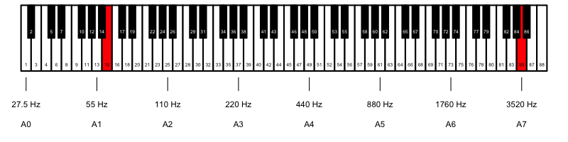

    Find $I$, the size of the interval in cents.

#### Solution

#### Question

32. In music, to compare two frequencies (to measure an interval), we can use cents.

    $$I = 1200 \cdot \log_2 \left(\frac{f_2}{f_1}\right)$$

    where $I$ is the size of the interval in cents, $f_1$ is the first frequency (typically in hertz), and $f_2$ is the second frequency.

    A pianist plays $C_{2}$ and $B_{2}$. On a [standard 88-key piano](https://en.wikipedia.org/wiki/Piano_key_frequencies), these notes correspond to key number $k_1=16$ and $k_2=27$, and their frequencies are $f_1\approx 65.4063913$ Hz and $f_2\approx 123.4708253$ Hz.

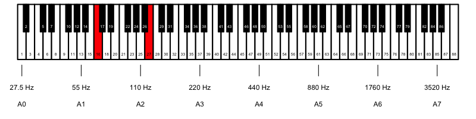

    Find $I$, the size of the interval in cents.

#### Solution

#### Question

33. In music, to compare two frequencies (to measure an interval), we can use cents.

    $$I = 1200 \cdot \log_2 \left(\frac{f_2}{f_1}\right)$$

    where $I$ is the size of the interval in cents, $f_1$ is the first frequency (typically in hertz), and $f_2$ is the second frequency.

    A pianist plays $G_{3}$ and $F_{4}$. On a [standard 88-key piano](https://en.wikipedia.org/wiki/Piano_key_frequencies), these notes correspond to key number $k_1=35$ and $k_2=45$, and their frequencies are $f_1\approx 195.997718$ Hz and $f_2\approx 349.2282314$ Hz.

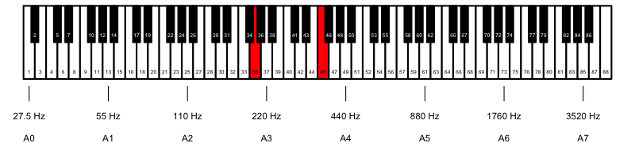

    Find $I$, the size of the interval in cents.

#### Solution

#### Question

34. In music, to compare two frequencies (to measure an interval), we can use cents.

    $$I = 1200 \cdot \log_2 \left(\frac{f_2}{f_1}\right)$$

    where $I$ is the size of the interval in cents, $f_1$ is the first frequency (typically in hertz), and $f_2$ is the second frequency.

    A pianist plays $C_{1}$ and $C_{3}$. On a [standard 88-key piano](https://en.wikipedia.org/wiki/Piano_key_frequencies), these notes correspond to key number $k_1=4$ and $k_2=28$, and their frequencies are $f_1\approx 32.7031957$ Hz and $f_2\approx 130.8127827$ Hz.

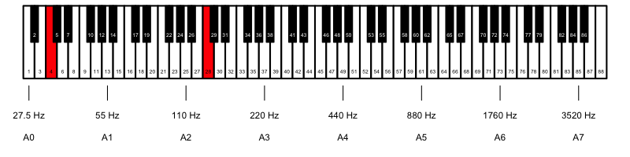

    Find $I$, the size of the interval in cents.

#### Solution

#### Question

35. In music, to compare two frequencies (to measure an interval), we can use cents.

    $$I = 1200 \cdot \log_2 \left(\frac{f_2}{f_1}\right)$$

    where $I$ is the size of the interval in cents, $f_1$ is the first frequency (typically in hertz), and $f_2$ is the second frequency.

    A pianist plays $D^{\#}_{3}$ and $G^{\#}_{5}$. On a [standard 88-key piano](https://en.wikipedia.org/wiki/Piano_key_frequencies), these notes correspond to key number $k_1=31$ and $k_2=60$, and their frequencies are $f_1\approx 155.5634919$ Hz and $f_2\approx 830.6093952$ Hz.

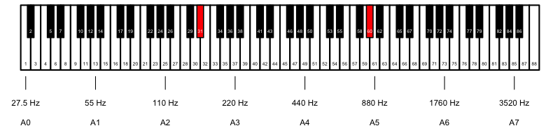

    Find $I$, the size of the interval in cents.

#### Solution

#### Question

36. In music, to compare two frequencies (to measure an interval), we can use cents.

    $$I = 1200 \cdot \log_2 \left(\frac{f_2}{f_1}\right)$$

    where $I$ is the size of the interval in cents, $f_1$ is the first frequency (typically in hertz), and $f_2$ is the second frequency.

    A pianist plays $C_{3}$ and $F^{\#}_{6}$. On a [standard 88-key piano](https://en.wikipedia.org/wiki/Piano_key_frequencies), these notes correspond to key number $k_1=28$ and $k_2=70$, and their frequencies are $f_1\approx 130.8127827$ Hz and $f_2\approx 1479.9776908$ Hz.

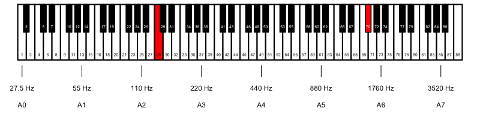

    Find $I$, the size of the interval in cents.

#### Solution

#### Question

37. In music, to compare two frequencies (to measure an interval), we can use cents.

    $$I = 1200 \cdot \log_2 \left(\frac{f_2}{f_1}\right)$$

    where $I$ is the size of the interval in cents, $f_1$ is the first frequency (typically in hertz), and $f_2$ is the second frequency.

    A pianist plays $F^{\#}_{2}$ and $F^{\#}_{4}$. On a [standard 88-key piano](https://en.wikipedia.org/wiki/Piano_key_frequencies), these notes correspond to key number $k_1=22$ and $k_2=46$, and their frequencies are $f_1\approx 92.4986057$ Hz and $f_2\approx 369.9944227$ Hz.

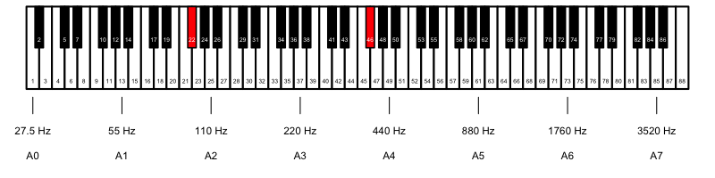

    Find $I$, the size of the interval in cents.

#### Solution

#### Question

38. In music, to compare two frequencies (to measure an interval), we can use cents.

    $$I = 1200 \cdot \log_2 \left(\frac{f_2}{f_1}\right)$$

    where $I$ is the size of the interval in cents, $f_1$ is the first frequency (typically in hertz), and $f_2$ is the second frequency.

    A pianist plays $G^{\#}_{6}$ and $C_{8}$. On a [standard 88-key piano](https://en.wikipedia.org/wiki/Piano_key_frequencies), these notes correspond to key number $k_1=72$ and $k_2=88$, and their frequencies are $f_1\approx 1661.2187903$ Hz and $f_2\approx 4186.0090448$ Hz.

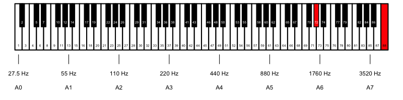

    Find $I$, the size of the interval in cents.

#### Solution

#### Question

39. In music, to compare two frequencies (to measure an interval), we can use cents.

    $$I = 1200 \cdot \log_2 \left(\frac{f_2}{f_1}\right)$$

    where $I$ is the size of the interval in cents, $f_1$ is the first frequency (typically in hertz), and $f_2$ is the second frequency.

    A pianist plays $D_{3}$ and $B_{6}$. On a [standard 88-key piano](https://en.wikipedia.org/wiki/Piano_key_frequencies), these notes correspond to key number $k_1=30$ and $k_2=75$, and their frequencies are $f_1\approx 146.832384$ Hz and $f_2\approx 1975.533205$ Hz.

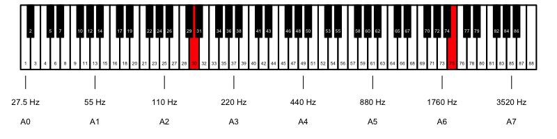

    Find $I$, the size of the interval in cents.

#### Solution

#### Question

40. In music, to compare two frequencies (to measure an interval), we can use cents.

    $$I = 1200 \cdot \log_2 \left(\frac{f_2}{f_1}\right)$$

    where $I$ is the size of the interval in cents, $f_1$ is the first frequency (typically in hertz), and $f_2$ is the second frequency.

    A pianist plays $D_{4}$ and $D^{\#}_{6}$. On a [standard 88-key piano](https://en.wikipedia.org/wiki/Piano_key_frequencies), these notes correspond to key number $k_1=42$ and $k_2=67$, and their frequencies are $f_1\approx 293.6647679$ Hz and $f_2\approx 1244.5079349$ Hz.

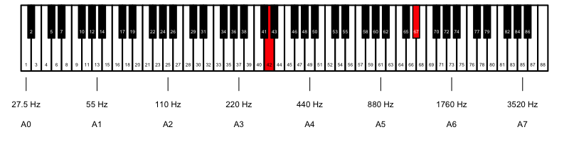

    Find $I$, the size of the interval in cents.

#### Solution

#### Question

41. A musician plays two notes. One note has a fundamental frequency of $f_1=36.708096$ Hz. The second frequency is 1300 cents above. **What is the second frequency?**

    Remember the way to calculate an interval in cents.
    $$I = 1200\cdot \log_2\left(\frac{f_2}{f_1}\right)$$

    with $I$ as the (signed) interval in cents, $f_1$ as the first frequency in hertz, and $f_2$ as the second frequency in hertz. We can solve the formula for $f_2$ because logarithms and exponentials are inverses.

    $$f_2 = f_1 \cdot 2^{I/1200}$$

#### Solution

#### Question

42. A musician plays two notes. One note has a fundamental frequency of $f_1=146.832384$ Hz. The second frequency is 4700 cents above. **What is the second frequency?**

    Remember the way to calculate an interval in cents.
    $$I = 1200\cdot \log_2\left(\frac{f_2}{f_1}\right)$$

    with $I$ as the (signed) interval in cents, $f_1$ as the first frequency in hertz, and $f_2$ as the second frequency in hertz. We can solve the formula for $f_2$ because logarithms and exponentials are inverses.

    $$f_2 = f_1 \cdot 2^{I/1200}$$

#### Solution

#### Question

43. A musician plays two notes. One note has a fundamental frequency of $f_1=932.327523$ Hz. The second frequency is 2200 cents less. **What is the second frequency?**

    Remember the way to calculate an interval in cents.
    $$I = 1200\cdot \log_2\left(\frac{f_2}{f_1}\right)$$

    with $I$ as the (signed) interval in cents, $f_1$ as the first frequency in hertz, and $f_2$ as the second frequency in hertz. We can solve the formula for $f_2$ because logarithms and exponentials are inverses.

    $$f_2 = f_1 \cdot 2^{I/1200}$$

#### Solution

#### Question

44. A musician plays two notes. One note has a fundamental frequency of $f_1=2349.3181433$ Hz. The second frequency is 1100 cents under. **What is the second frequency?**

    Remember the way to calculate an interval in cents.
    $$I = 1200\cdot \log_2\left(\frac{f_2}{f_1}\right)$$

    with $I$ as the (signed) interval in cents, $f_1$ as the first frequency in hertz, and $f_2$ as the second frequency in hertz. We can solve the formula for $f_2$ because logarithms and exponentials are inverses.

    $$f_2 = f_1 \cdot 2^{I/1200}$$

#### Solution

#### Question

45. A musician plays two notes. One note has a fundamental frequency of $f_1=1567.9817439$ Hz. The second frequency is 600 cents over. **What is the second frequency?**

    Remember the way to calculate an interval in cents.
    $$I = 1200\cdot \log_2\left(\frac{f_2}{f_1}\right)$$

    with $I$ as the (signed) interval in cents, $f_1$ as the first frequency in hertz, and $f_2$ as the second frequency in hertz. We can solve the formula for $f_2$ because logarithms and exponentials are inverses.

    $$f_2 = f_1 \cdot 2^{I/1200}$$

#### Solution

#### Question

46. A musician plays two notes. One note has a fundamental frequency of $f_1=261.6255653$ Hz. The second frequency is 900 cents less. **What is the second frequency?**

    Remember the way to calculate an interval in cents.
    $$I = 1200\cdot \log_2\left(\frac{f_2}{f_1}\right)$$

    with $I$ as the (signed) interval in cents, $f_1$ as the first frequency in hertz, and $f_2$ as the second frequency in hertz. We can solve the formula for $f_2$ because logarithms and exponentials are inverses.

    $$f_2 = f_1 \cdot 2^{I/1200}$$

#### Solution

#### Question

47. A musician plays two notes. One note has a fundamental frequency of $f_1=164.8137785$ Hz. The second frequency is 900 cents under. **What is the second frequency?**

    Remember the way to calculate an interval in cents.
    $$I = 1200\cdot \log_2\left(\frac{f_2}{f_1}\right)$$

    with $I$ as the (signed) interval in cents, $f_1$ as the first frequency in hertz, and $f_2$ as the second frequency in hertz. We can solve the formula for $f_2$ because logarithms and exponentials are inverses.

    $$f_2 = f_1 \cdot 2^{I/1200}$$

#### Solution

#### Question

48. A musician plays two notes. One note has a fundamental frequency of $f_1=3951.06641$ Hz. The second frequency is 4300 cents below. **What is the second frequency?**

    Remember the way to calculate an interval in cents.
    $$I = 1200\cdot \log_2\left(\frac{f_2}{f_1}\right)$$

    with $I$ as the (signed) interval in cents, $f_1$ as the first frequency in hertz, and $f_2$ as the second frequency in hertz. We can solve the formula for $f_2$ because logarithms and exponentials are inverses.

    $$f_2 = f_1 \cdot 2^{I/1200}$$

#### Solution

#### Question

49. A musician plays two notes. One note has a fundamental frequency of $f_1=155.5634919$ Hz. The second frequency is 1900 cents more. **What is the second frequency?**

    Remember the way to calculate an interval in cents.
    $$I = 1200\cdot \log_2\left(\frac{f_2}{f_1}\right)$$

    with $I$ as the (signed) interval in cents, $f_1$ as the first frequency in hertz, and $f_2$ as the second frequency in hertz. We can solve the formula for $f_2$ because logarithms and exponentials are inverses.

    $$f_2 = f_1 \cdot 2^{I/1200}$$

#### Solution

#### Question

50. A musician plays two notes. One note has a fundamental frequency of $f_1=27.5$ Hz. The second frequency is 800 cents over. **What is the second frequency?**

    Remember the way to calculate an interval in cents.
    $$I = 1200\cdot \log_2\left(\frac{f_2}{f_1}\right)$$

    with $I$ as the (signed) interval in cents, $f_1$ as the first frequency in hertz, and $f_2$ as the second frequency in hertz. We can solve the formula for $f_2$ because logarithms and exponentials are inverses.

    $$f_2 = f_1 \cdot 2^{I/1200}$$

#### Solution

#### Question

51. When the ratio between two [fundamental frequencies](https://en.wikipedia.org/wiki/Fundamental_frequency) is near 3:2, musicians call the interval a “fifth”, named from playing the first and fifth notes in a classical [diatonic scale](https://en.wikipedia.org/wiki/Diatonic_scale). Somewhat annoyingly, [equal temperament](https://en.wikipedia.org/wiki/Equal_temperament) does not allow for a ratio of exactly 3:2. Some equal temperaments get closer than others. Let’s investigate how close [23 EDO](https://en.wikipedia.org/wiki/Equal_temperament#Various_equal_temperaments) can get to an [exact 3:2 ratio of frequencies](https://en.wikipedia.org/wiki/Just_intonation).

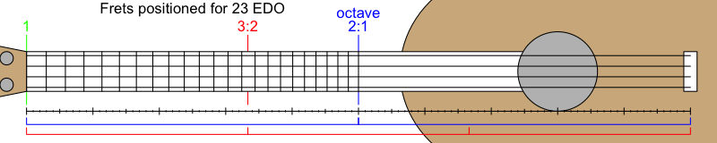

    First, determine the cents of an exact 3:2 ratio.

    $$I_\text{exact} ~=~ 1200\cdot\log_2(1.5) ~=~ 701.9550009$$

    Determine the best [fret](https://en.wikipedia.org/wiki/Fret) by [rounding](https://en.wikipedia.org/wiki/Rounding#Rounding_to_the_nearest_integer) a logarithmic function.

    $$x ~=~ \text{round} \left(23\cdot \log_2(1.5) \right)$$
    Then, determine the ratio of frequencies between an open string and the $x$th fret. It should be near 1.5, but a bit off.

    $$r = 2^{x/23}$$

    Calculate the cents of the interval between the open string and the $x$th fret.

    $$I_{\text{fret}} = 1200 \cdot \log_2(r)$$

    Finally, determine the absolute difference.

    $$\text{answer} = \left|I_{\text{fret}} - I_{\text{exact}}\right|$$

    Your answer can be rounded to the nearest cent.

#### Solution

#### Question

52. When the ratio between two [fundamental frequencies](https://en.wikipedia.org/wiki/Fundamental_frequency) is near 3:2, musicians call the interval a “fifth”, named from playing the first and fifth notes in a classical [diatonic scale](https://en.wikipedia.org/wiki/Diatonic_scale). Somewhat annoyingly, [equal temperament](https://en.wikipedia.org/wiki/Equal_temperament) does not allow for a ratio of exactly 3:2. Some equal temperaments get closer than others. Let’s investigate how close [35 EDO](https://en.wikipedia.org/wiki/Equal_temperament#Various_equal_temperaments) can get to an [exact 3:2 ratio of frequencies](https://en.wikipedia.org/wiki/Just_intonation).

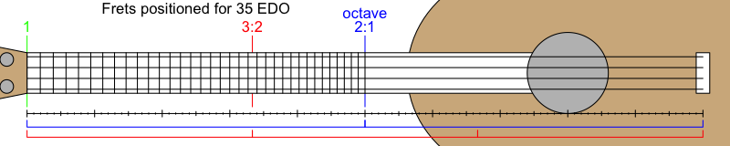

    First, determine the cents of an exact 3:2 ratio.

    $$I_\text{exact} ~=~ 1200\cdot\log_2(1.5) ~=~ 701.9550009$$

    Determine the best [fret](https://en.wikipedia.org/wiki/Fret) by [rounding](https://en.wikipedia.org/wiki/Rounding#Rounding_to_the_nearest_integer) a logarithmic function.

    $$x ~=~ \text{round} \left(35\cdot \log_2(1.5) \right)$$
    Then, determine the ratio of frequencies between an open string and the $x$th fret. It should be near 1.5, but a bit off.

    $$r = 2^{x/35}$$

    Calculate the cents of the interval between the open string and the $x$th fret.

    $$I_{\text{fret}} = 1200 \cdot \log_2(r)$$

    Finally, determine the absolute difference.

    $$\text{answer} = \left|I_{\text{fret}} - I_{\text{exact}}\right|$$

    Your answer can be rounded to the nearest cent.

#### Solution

#### Question

53. When the ratio between two [fundamental frequencies](https://en.wikipedia.org/wiki/Fundamental_frequency) is near 3:2, musicians call the interval a “fifth”, named from playing the first and fifth notes in a classical [diatonic scale](https://en.wikipedia.org/wiki/Diatonic_scale). Somewhat annoyingly, [equal temperament](https://en.wikipedia.org/wiki/Equal_temperament) does not allow for a ratio of exactly 3:2. Some equal temperaments get closer than others. Let’s investigate how close [18 EDO](https://en.wikipedia.org/wiki/Equal_temperament#Various_equal_temperaments) can get to an [exact 3:2 ratio of frequencies](https://en.wikipedia.org/wiki/Just_intonation).

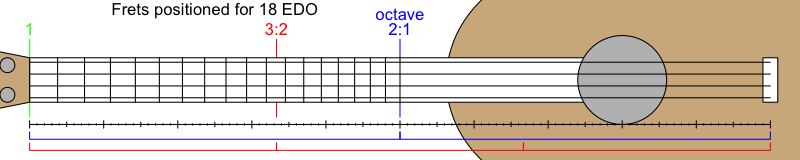

    First, determine the cents of an exact 3:2 ratio.

    $$I_\text{exact} ~=~ 1200\cdot\log_2(1.5) ~=~ 701.9550009$$

    Determine the best [fret](https://en.wikipedia.org/wiki/Fret) by [rounding](https://en.wikipedia.org/wiki/Rounding#Rounding_to_the_nearest_integer) a logarithmic function.

    $$x ~=~ \text{round} \left(18\cdot \log_2(1.5) \right)$$
    Then, determine the ratio of frequencies between an open string and the $x$th fret. It should be near 1.5, but a bit off.

    $$r = 2^{x/18}$$

    Calculate the cents of the interval between the open string and the $x$th fret.

    $$I_{\text{fret}} = 1200 \cdot \log_2(r)$$

    Finally, determine the absolute difference.

    $$\text{answer} = \left|I_{\text{fret}} - I_{\text{exact}}\right|$$

    Your answer can be rounded to the nearest cent.

#### Solution

#### Question

54. When the ratio between two [fundamental frequencies](https://en.wikipedia.org/wiki/Fundamental_frequency) is near 3:2, musicians call the interval a “fifth”, named from playing the first and fifth notes in a classical [diatonic scale](https://en.wikipedia.org/wiki/Diatonic_scale). Somewhat annoyingly, [equal temperament](https://en.wikipedia.org/wiki/Equal_temperament) does not allow for a ratio of exactly 3:2. Some equal temperaments get closer than others. Let’s investigate how close [6 EDO](https://en.wikipedia.org/wiki/Equal_temperament#Various_equal_temperaments) can get to an [exact 3:2 ratio of frequencies](https://en.wikipedia.org/wiki/Just_intonation).

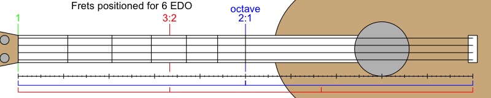

    First, determine the cents of an exact 3:2 ratio.

    $$I_\text{exact} ~=~ 1200\cdot\log_2(1.5) ~=~ 701.9550009$$

    Determine the best [fret](https://en.wikipedia.org/wiki/Fret) by [rounding](https://en.wikipedia.org/wiki/Rounding#Rounding_to_the_nearest_integer) a logarithmic function.

    $$x ~=~ \text{round} \left(6\cdot \log_2(1.5) \right)$$
    Then, determine the ratio of frequencies between an open string and the $x$th fret. It should be near 1.5, but a bit off.

    $$r = 2^{x/6}$$

    Calculate the cents of the interval between the open string and the $x$th fret.

    $$I_{\text{fret}} = 1200 \cdot \log_2(r)$$

    Finally, determine the absolute difference.

    $$\text{answer} = \left|I_{\text{fret}} - I_{\text{exact}}\right|$$

    Your answer can be rounded to the nearest cent.

#### Solution

#### Question

55. When the ratio between two [fundamental frequencies](https://en.wikipedia.org/wiki/Fundamental_frequency) is near 3:2, musicians call the interval a “fifth”, named from playing the first and fifth notes in a classical [diatonic scale](https://en.wikipedia.org/wiki/Diatonic_scale). Somewhat annoyingly, [equal temperament](https://en.wikipedia.org/wiki/Equal_temperament) does not allow for a ratio of exactly 3:2. Some equal temperaments get closer than others. Let’s investigate how close [30 EDO](https://en.wikipedia.org/wiki/Equal_temperament#Various_equal_temperaments) can get to an [exact 3:2 ratio of frequencies](https://en.wikipedia.org/wiki/Just_intonation).

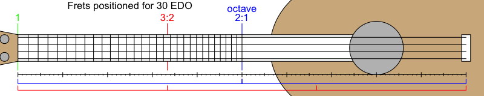

    First, determine the cents of an exact 3:2 ratio.

    $$I_\text{exact} ~=~ 1200\cdot\log_2(1.5) ~=~ 701.9550009$$

    Determine the best [fret](https://en.wikipedia.org/wiki/Fret) by [rounding](https://en.wikipedia.org/wiki/Rounding#Rounding_to_the_nearest_integer) a logarithmic function.

    $$x ~=~ \text{round} \left(30\cdot \log_2(1.5) \right)$$
    Then, determine the ratio of frequencies between an open string and the $x$th fret. It should be near 1.5, but a bit off.

    $$r = 2^{x/30}$$

    Calculate the cents of the interval between the open string and the $x$th fret.

    $$I_{\text{fret}} = 1200 \cdot \log_2(r)$$

    Finally, determine the absolute difference.

    $$\text{answer} = \left|I_{\text{fret}} - I_{\text{exact}}\right|$$

    Your answer can be rounded to the nearest cent.

#### Solution

#### Question

56. When the ratio between two [fundamental frequencies](https://en.wikipedia.org/wiki/Fundamental_frequency) is near 3:2, musicians call the interval a “fifth”, named from playing the first and fifth notes in a classical [diatonic scale](https://en.wikipedia.org/wiki/Diatonic_scale). Somewhat annoyingly, [equal temperament](https://en.wikipedia.org/wiki/Equal_temperament) does not allow for a ratio of exactly 3:2. Some equal temperaments get closer than others. Let’s investigate how close [5 EDO](https://en.wikipedia.org/wiki/Equal_temperament#Various_equal_temperaments) can get to an [exact 3:2 ratio of frequencies](https://en.wikipedia.org/wiki/Just_intonation).

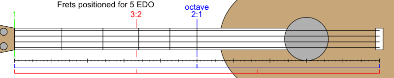

    First, determine the cents of an exact 3:2 ratio.

    $$I_\text{exact} ~=~ 1200\cdot\log_2(1.5) ~=~ 701.9550009$$

    Determine the best [fret](https://en.wikipedia.org/wiki/Fret) by [rounding](https://en.wikipedia.org/wiki/Rounding#Rounding_to_the_nearest_integer) a logarithmic function.

    $$x ~=~ \text{round} \left(5\cdot \log_2(1.5) \right)$$
    Then, determine the ratio of frequencies between an open string and the $x$th fret. It should be near 1.5, but a bit off.

    $$r = 2^{x/5}$$

    Calculate the cents of the interval between the open string and the $x$th fret.

    $$I_{\text{fret}} = 1200 \cdot \log_2(r)$$

    Finally, determine the absolute difference.

    $$\text{answer} = \left|I_{\text{fret}} - I_{\text{exact}}\right|$$

    Your answer can be rounded to the nearest cent.

#### Solution

#### Question

57. When the ratio between two [fundamental frequencies](https://en.wikipedia.org/wiki/Fundamental_frequency) is near 3:2, musicians call the interval a “fifth”, named from playing the first and fifth notes in a classical [diatonic scale](https://en.wikipedia.org/wiki/Diatonic_scale). Somewhat annoyingly, [equal temperament](https://en.wikipedia.org/wiki/Equal_temperament) does not allow for a ratio of exactly 3:2. Some equal temperaments get closer than others. Let’s investigate how close [11 EDO](https://en.wikipedia.org/wiki/Equal_temperament#Various_equal_temperaments) can get to an [exact 3:2 ratio of frequencies](https://en.wikipedia.org/wiki/Just_intonation).

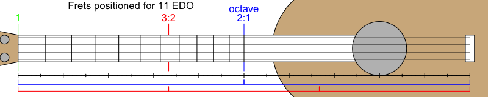

    First, determine the cents of an exact 3:2 ratio.

    $$I_\text{exact} ~=~ 1200\cdot\log_2(1.5) ~=~ 701.9550009$$

    Determine the best [fret](https://en.wikipedia.org/wiki/Fret) by [rounding](https://en.wikipedia.org/wiki/Rounding#Rounding_to_the_nearest_integer) a logarithmic function.

    $$x ~=~ \text{round} \left(11\cdot \log_2(1.5) \right)$$
    Then, determine the ratio of frequencies between an open string and the $x$th fret. It should be near 1.5, but a bit off.

    $$r = 2^{x/11}$$

    Calculate the cents of the interval between the open string and the $x$th fret.

    $$I_{\text{fret}} = 1200 \cdot \log_2(r)$$

    Finally, determine the absolute difference.

    $$\text{answer} = \left|I_{\text{fret}} - I_{\text{exact}}\right|$$

    Your answer can be rounded to the nearest cent.

#### Solution

#### Question

58. When the ratio between two [fundamental frequencies](https://en.wikipedia.org/wiki/Fundamental_frequency) is near 3:2, musicians call the interval a “fifth”, named from playing the first and fifth notes in a classical [diatonic scale](https://en.wikipedia.org/wiki/Diatonic_scale). Somewhat annoyingly, [equal temperament](https://en.wikipedia.org/wiki/Equal_temperament) does not allow for a ratio of exactly 3:2. Some equal temperaments get closer than others. Let’s investigate how close [39 EDO](https://en.wikipedia.org/wiki/Equal_temperament#Various_equal_temperaments) can get to an [exact 3:2 ratio of frequencies](https://en.wikipedia.org/wiki/Just_intonation).

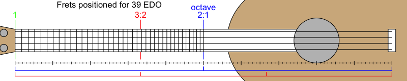

    First, determine the cents of an exact 3:2 ratio.

    $$I_\text{exact} ~=~ 1200\cdot\log_2(1.5) ~=~ 701.9550009$$

    Determine the best [fret](https://en.wikipedia.org/wiki/Fret) by [rounding](https://en.wikipedia.org/wiki/Rounding#Rounding_to_the_nearest_integer) a logarithmic function.

    $$x ~=~ \text{round} \left(39\cdot \log_2(1.5) \right)$$
    Then, determine the ratio of frequencies between an open string and the $x$th fret. It should be near 1.5, but a bit off.

    $$r = 2^{x/39}$$

    Calculate the cents of the interval between the open string and the $x$th fret.

    $$I_{\text{fret}} = 1200 \cdot \log_2(r)$$

    Finally, determine the absolute difference.

    $$\text{answer} = \left|I_{\text{fret}} - I_{\text{exact}}\right|$$

    Your answer can be rounded to the nearest cent.

#### Solution

#### Question

59. When the ratio between two [fundamental frequencies](https://en.wikipedia.org/wiki/Fundamental_frequency) is near 3:2, musicians call the interval a “fifth”, named from playing the first and fifth notes in a classical [diatonic scale](https://en.wikipedia.org/wiki/Diatonic_scale). Somewhat annoyingly, [equal temperament](https://en.wikipedia.org/wiki/Equal_temperament) does not allow for a ratio of exactly 3:2. Some equal temperaments get closer than others. Let’s investigate how close [19 EDO](https://en.wikipedia.org/wiki/Equal_temperament#Various_equal_temperaments) can get to an [exact 3:2 ratio of frequencies](https://en.wikipedia.org/wiki/Just_intonation).

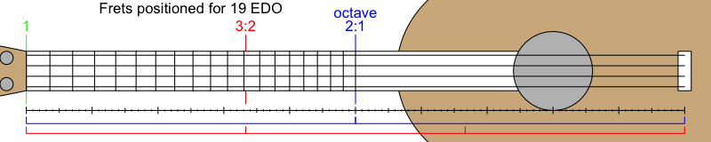

    First, determine the cents of an exact 3:2 ratio.

    $$I_\text{exact} ~=~ 1200\cdot\log_2(1.5) ~=~ 701.9550009$$

    Determine the best [fret](https://en.wikipedia.org/wiki/Fret) by [rounding](https://en.wikipedia.org/wiki/Rounding#Rounding_to_the_nearest_integer) a logarithmic function.

    $$x ~=~ \text{round} \left(19\cdot \log_2(1.5) \right)$$
    Then, determine the ratio of frequencies between an open string and the $x$th fret. It should be near 1.5, but a bit off.

    $$r = 2^{x/19}$$

    Calculate the cents of the interval between the open string and the $x$th fret.

    $$I_{\text{fret}} = 1200 \cdot \log_2(r)$$

    Finally, determine the absolute difference.

    $$\text{answer} = \left|I_{\text{fret}} - I_{\text{exact}}\right|$$

    Your answer can be rounded to the nearest cent.

#### Solution

#### Question

60. When the ratio between two [fundamental frequencies](https://en.wikipedia.org/wiki/Fundamental_frequency) is near 3:2, musicians call the interval a “fifth”, named from playing the first and fifth notes in a classical [diatonic scale](https://en.wikipedia.org/wiki/Diatonic_scale). Somewhat annoyingly, [equal temperament](https://en.wikipedia.org/wiki/Equal_temperament) does not allow for a ratio of exactly 3:2. Some equal temperaments get closer than others. Let’s investigate how close [29 EDO](https://en.wikipedia.org/wiki/Equal_temperament#Various_equal_temperaments) can get to an [exact 3:2 ratio of frequencies](https://en.wikipedia.org/wiki/Just_intonation).

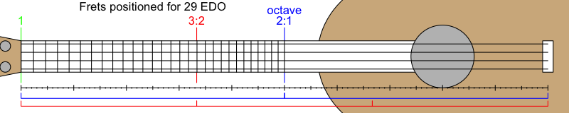

    First, determine the cents of an exact 3:2 ratio.

    $$I_\text{exact} ~=~ 1200\cdot\log_2(1.5) ~=~ 701.9550009$$

    Determine the best [fret](https://en.wikipedia.org/wiki/Fret) by [rounding](https://en.wikipedia.org/wiki/Rounding#Rounding_to_the_nearest_integer) a logarithmic function.

    $$x ~=~ \text{round} \left(29\cdot \log_2(1.5) \right)$$
    Then, determine the ratio of frequencies between an open string and the $x$th fret. It should be near 1.5, but a bit off.

    $$r = 2^{x/29}$$

    Calculate the cents of the interval between the open string and the $x$th fret.

    $$I_{\text{fret}} = 1200 \cdot \log_2(r)$$

    Finally, determine the absolute difference.

    $$\text{answer} = \left|I_{\text{fret}} - I_{\text{exact}}\right|$$

    Your answer can be rounded to the nearest cent.

#### Solution

#### Question

61. An investment earns [compound interest](https://en.wikipedia.org/wiki/Compound_interest#Periodic_compounding) with periodic compounding.
    - Principal = $P=90000$ USD
    - Nominal [annual interest rate](https://en.wikipedia.org/wiki/Annual_percentage_rate#Multiple_definitions_of_effective_APR) = $r~=~0.04 ~=~4\%$
    - Compounding frequency = $n=6$ per year
    - Time = $t=20$ years

    Calculate the amount, in USD, after 20 years.

    $$A = P\left(1+\frac{r}{n}\right)^{\lfloor nt \rfloor}$$
    For the final amount, you can ignore the [floor](https://en.wikipedia.org/wiki/Floor_and_ceiling_functions) function, as $nt$ is an integer. You can round to the nearest penny. (*Tolerance is $\pm 1$*)

#### Solution

#### Question

62. An investment earns [compound interest](https://en.wikipedia.org/wiki/Compound_interest#Periodic_compounding) with periodic compounding.
    - Principal = $P=580$ USD
    - Nominal [annual interest rate](https://en.wikipedia.org/wiki/Annual_percentage_rate#Multiple_definitions_of_effective_APR) = $r~=~0.05 ~=~5\%$
    - Compounding frequency = $n=4$ per year
    - Time = $t=20$ years

    Calculate the amount, in USD, after 20 years.

    $$A = P\left(1+\frac{r}{n}\right)^{\lfloor nt \rfloor}$$
    For the final amount, you can ignore the [floor](https://en.wikipedia.org/wiki/Floor_and_ceiling_functions) function, as $nt$ is an integer. You can round to the nearest penny. (*Tolerance is $\pm 1$*)

#### Solution

#### Question

63. An investment earns [compound interest](https://en.wikipedia.org/wiki/Compound_interest#Periodic_compounding) with periodic compounding.
    - Principal = $P=7200$ USD
    - Nominal [annual interest rate](https://en.wikipedia.org/wiki/Annual_percentage_rate#Multiple_definitions_of_effective_APR) = $r~=~0.04 ~=~4\%$
    - Compounding frequency = $n=12$ per year
    - Time = $t=30$ years

    Calculate the amount, in USD, after 30 years.

    $$A = P\left(1+\frac{r}{n}\right)^{\lfloor nt \rfloor}$$
    For the final amount, you can ignore the [floor](https://en.wikipedia.org/wiki/Floor_and_ceiling_functions) function, as $nt$ is an integer. You can round to the nearest penny. (*Tolerance is $\pm 1$*)

#### Solution

#### Question

64. An investment earns [compound interest](https://en.wikipedia.org/wiki/Compound_interest#Periodic_compounding) with periodic compounding.
    - Principal = $P=69000$ USD
    - Nominal [annual interest rate](https://en.wikipedia.org/wiki/Annual_percentage_rate#Multiple_definitions_of_effective_APR) = $r~=~0.02 ~=~2\%$
    - Compounding frequency = $n=3$ per year
    - Time = $t=25$ years

    Calculate the amount, in USD, after 25 years.

    $$A = P\left(1+\frac{r}{n}\right)^{\lfloor nt \rfloor}$$
    For the final amount, you can ignore the [floor](https://en.wikipedia.org/wiki/Floor_and_ceiling_functions) function, as $nt$ is an integer. You can round to the nearest penny. (*Tolerance is $\pm 1$*)

#### Solution

#### Question

65. An investment earns [compound interest](https://en.wikipedia.org/wiki/Compound_interest#Periodic_compounding) with periodic compounding.
    - Principal = $P=2900$ USD
    - Nominal [annual interest rate](https://en.wikipedia.org/wiki/Annual_percentage_rate#Multiple_definitions_of_effective_APR) = $r~=~0.02 ~=~2\%$
    - Compounding frequency = $n=12$ per year
    - Time = $t=30$ years

    Calculate the amount, in USD, after 30 years.

    $$A = P\left(1+\frac{r}{n}\right)^{\lfloor nt \rfloor}$$
    For the final amount, you can ignore the [floor](https://en.wikipedia.org/wiki/Floor_and_ceiling_functions) function, as $nt$ is an integer. You can round to the nearest penny. (*Tolerance is $\pm 1$*)

#### Solution

#### Question

66. An investment earns [compound interest](https://en.wikipedia.org/wiki/Compound_interest#Periodic_compounding) with periodic compounding.
    - Principal = $P=5900$ USD
    - Nominal [annual interest rate](https://en.wikipedia.org/wiki/Annual_percentage_rate#Multiple_definitions_of_effective_APR) = $r~=~0.04 ~=~4\%$
    - Compounding frequency = $n=2$ per year
    - Time = $t=10$ years

    Calculate the amount, in USD, after 10 years.

    $$A = P\left(1+\frac{r}{n}\right)^{\lfloor nt \rfloor}$$
    For the final amount, you can ignore the [floor](https://en.wikipedia.org/wiki/Floor_and_ceiling_functions) function, as $nt$ is an integer. You can round to the nearest penny. (*Tolerance is $\pm 1$*)

#### Solution

#### Question

67. An investment earns [compound interest](https://en.wikipedia.org/wiki/Compound_interest#Periodic_compounding) with periodic compounding.
    - Principal = $P=270$ USD
    - Nominal [annual interest rate](https://en.wikipedia.org/wiki/Annual_percentage_rate#Multiple_definitions_of_effective_APR) = $r~=~0.06 ~=~6\%$
    - Compounding frequency = $n=4$ per year
    - Time = $t=10$ years

    Calculate the amount, in USD, after 10 years.

    $$A = P\left(1+\frac{r}{n}\right)^{\lfloor nt \rfloor}$$
    For the final amount, you can ignore the [floor](https://en.wikipedia.org/wiki/Floor_and_ceiling_functions) function, as $nt$ is an integer. You can round to the nearest penny. (*Tolerance is $\pm 1$*)

#### Solution

#### Question

68. An investment earns [compound interest](https://en.wikipedia.org/wiki/Compound_interest#Periodic_compounding) with periodic compounding.
    - Principal = $P=7100$ USD
    - Nominal [annual interest rate](https://en.wikipedia.org/wiki/Annual_percentage_rate#Multiple_definitions_of_effective_APR) = $r~=~0.07 ~=~7\%$
    - Compounding frequency = $n=4$ per year
    - Time = $t=10$ years

    Calculate the amount, in USD, after 10 years.

    $$A = P\left(1+\frac{r}{n}\right)^{\lfloor nt \rfloor}$$
    For the final amount, you can ignore the [floor](https://en.wikipedia.org/wiki/Floor_and_ceiling_functions) function, as $nt$ is an integer. You can round to the nearest penny. (*Tolerance is $\pm 1$*)

#### Solution

#### Question

69. An investment earns [compound interest](https://en.wikipedia.org/wiki/Compound_interest#Periodic_compounding) with periodic compounding.
    - Principal = $P=7400$ USD
    - Nominal [annual interest rate](https://en.wikipedia.org/wiki/Annual_percentage_rate#Multiple_definitions_of_effective_APR) = $r~=~0.05 ~=~5\%$
    - Compounding frequency = $n=4$ per year
    - Time = $t=25$ years

    Calculate the amount, in USD, after 25 years.

    $$A = P\left(1+\frac{r}{n}\right)^{\lfloor nt \rfloor}$$
    For the final amount, you can ignore the [floor](https://en.wikipedia.org/wiki/Floor_and_ceiling_functions) function, as $nt$ is an integer. You can round to the nearest penny. (*Tolerance is $\pm 1$*)

#### Solution

#### Question

70. An investment earns [compound interest](https://en.wikipedia.org/wiki/Compound_interest#Periodic_compounding) with periodic compounding.
    - Principal = $P=270$ USD
    - Nominal [annual interest rate](https://en.wikipedia.org/wiki/Annual_percentage_rate#Multiple_definitions_of_effective_APR) = $r~=~0.03 ~=~3\%$
    - Compounding frequency = $n=2$ per year
    - Time = $t=25$ years

    Calculate the amount, in USD, after 25 years.

    $$A = P\left(1+\frac{r}{n}\right)^{\lfloor nt \rfloor}$$
    For the final amount, you can ignore the [floor](https://en.wikipedia.org/wiki/Floor_and_ceiling_functions) function, as $nt$ is an integer. You can round to the nearest penny. (*Tolerance is $\pm 1$*)

#### Solution

#### Question

71. An investment earns compound interest with [continuous compounding](https://en.wikipedia.org/wiki/Compound_interest#Continuous_compounding).
    - Principal = $P=3500$ USD
    - Nominal [annual interest rate](https://en.wikipedia.org/wiki/Annual_percentage_rate#Multiple_definitions_of_effective_APR) = $r~=~0.08 ~=~8\%$
    - Compounding frequency = $n\to\infty$ per year
    - Time = $t=25$ years

    Calculate the amount, in USD, after 25 years.

    $$A ~=~ \lim_{n\to\infty} P\left(1+\frac{r}{n}\right)^{nt} ~=~ Pe^{rt}$$
    Euler’s number, $e$, is approximately 2.7182818. You can round to the nearest dollar. (*Tolerance is $\pm 1$*.)

#### Solution

#### Question

72. An investment earns compound interest with [continuous compounding](https://en.wikipedia.org/wiki/Compound_interest#Continuous_compounding).
    - Principal = $P=850$ USD
    - Nominal [annual interest rate](https://en.wikipedia.org/wiki/Annual_percentage_rate#Multiple_definitions_of_effective_APR) = $r~=~0.09 ~=~9\%$
    - Compounding frequency = $n\to\infty$ per year
    - Time = $t=15$ years

    Calculate the amount, in USD, after 15 years.

    $$A ~=~ \lim_{n\to\infty} P\left(1+\frac{r}{n}\right)^{nt} ~=~ Pe^{rt}$$
    Euler’s number, $e$, is approximately 2.7182818. You can round to the nearest dollar. (*Tolerance is $\pm 1$*.)

#### Solution

#### Question

73. An investment earns compound interest with [continuous compounding](https://en.wikipedia.org/wiki/Compound_interest#Continuous_compounding).
    - Principal = $P=9300$ USD
    - Nominal [annual interest rate](https://en.wikipedia.org/wiki/Annual_percentage_rate#Multiple_definitions_of_effective_APR) = $r~=~0.08 ~=~8\%$
    - Compounding frequency = $n\to\infty$ per year
    - Time = $t=20$ years

    Calculate the amount, in USD, after 20 years.

    $$A ~=~ \lim_{n\to\infty} P\left(1+\frac{r}{n}\right)^{nt} ~=~ Pe^{rt}$$
    Euler’s number, $e$, is approximately 2.7182818. You can round to the nearest dollar. (*Tolerance is $\pm 1$*.)

#### Solution

#### Question

74. An investment earns compound interest with [continuous compounding](https://en.wikipedia.org/wiki/Compound_interest#Continuous_compounding).
    - Principal = $P=7400$ USD
    - Nominal [annual interest rate](https://en.wikipedia.org/wiki/Annual_percentage_rate#Multiple_definitions_of_effective_APR) = $r~=~0.02 ~=~2\%$
    - Compounding frequency = $n\to\infty$ per year
    - Time = $t=25$ years

    Calculate the amount, in USD, after 25 years.

    $$A ~=~ \lim_{n\to\infty} P\left(1+\frac{r}{n}\right)^{nt} ~=~ Pe^{rt}$$
    Euler’s number, $e$, is approximately 2.7182818. You can round to the nearest dollar. (*Tolerance is $\pm 1$*.)

#### Solution

#### Question

75. An investment earns compound interest with [continuous compounding](https://en.wikipedia.org/wiki/Compound_interest#Continuous_compounding).
    - Principal = $P=2200$ USD
    - Nominal [annual interest rate](https://en.wikipedia.org/wiki/Annual_percentage_rate#Multiple_definitions_of_effective_APR) = $r~=~0.08 ~=~8\%$
    - Compounding frequency = $n\to\infty$ per year
    - Time = $t=10$ years

    Calculate the amount, in USD, after 10 years.

    $$A ~=~ \lim_{n\to\infty} P\left(1+\frac{r}{n}\right)^{nt} ~=~ Pe^{rt}$$
    Euler’s number, $e$, is approximately 2.7182818. You can round to the nearest dollar. (*Tolerance is $\pm 1$*.)

#### Solution

#### Question

76. An investment earns compound interest with [continuous compounding](https://en.wikipedia.org/wiki/Compound_interest#Continuous_compounding).
    - Principal = $P=5800$ USD
    - Nominal [annual interest rate](https://en.wikipedia.org/wiki/Annual_percentage_rate#Multiple_definitions_of_effective_APR) = $r~=~0.07 ~=~7\%$
    - Compounding frequency = $n\to\infty$ per year
    - Time = $t=30$ years

    Calculate the amount, in USD, after 30 years.

    $$A ~=~ \lim_{n\to\infty} P\left(1+\frac{r}{n}\right)^{nt} ~=~ Pe^{rt}$$
    Euler’s number, $e$, is approximately 2.7182818. You can round to the nearest dollar. (*Tolerance is $\pm 1$*.)

#### Solution

#### Question

77. An investment earns compound interest with [continuous compounding](https://en.wikipedia.org/wiki/Compound_interest#Continuous_compounding).
    - Principal = $P=750$ USD
    - Nominal [annual interest rate](https://en.wikipedia.org/wiki/Annual_percentage_rate#Multiple_definitions_of_effective_APR) = $r~=~0.06 ~=~6\%$
    - Compounding frequency = $n\to\infty$ per year
    - Time = $t=20$ years

    Calculate the amount, in USD, after 20 years.

    $$A ~=~ \lim_{n\to\infty} P\left(1+\frac{r}{n}\right)^{nt} ~=~ Pe^{rt}$$
    Euler’s number, $e$, is approximately 2.7182818. You can round to the nearest dollar. (*Tolerance is $\pm 1$*.)

#### Solution

#### Question

78. An investment earns compound interest with [continuous compounding](https://en.wikipedia.org/wiki/Compound_interest#Continuous_compounding).
    - Principal = $P=22000$ USD
    - Nominal [annual interest rate](https://en.wikipedia.org/wiki/Annual_percentage_rate#Multiple_definitions_of_effective_APR) = $r~=~0.08 ~=~8\%$
    - Compounding frequency = $n\to\infty$ per year
    - Time = $t=15$ years

    Calculate the amount, in USD, after 15 years.

    $$A ~=~ \lim_{n\to\infty} P\left(1+\frac{r}{n}\right)^{nt} ~=~ Pe^{rt}$$
    Euler’s number, $e$, is approximately 2.7182818. You can round to the nearest dollar. (*Tolerance is $\pm 1$*.)

#### Solution

#### Question

79. An investment earns compound interest with [continuous compounding](https://en.wikipedia.org/wiki/Compound_interest#Continuous_compounding).
    - Principal = $P=4000$ USD
    - Nominal [annual interest rate](https://en.wikipedia.org/wiki/Annual_percentage_rate#Multiple_definitions_of_effective_APR) = $r~=~0.05 ~=~5\%$
    - Compounding frequency = $n\to\infty$ per year
    - Time = $t=15$ years

    Calculate the amount, in USD, after 15 years.

    $$A ~=~ \lim_{n\to\infty} P\left(1+\frac{r}{n}\right)^{nt} ~=~ Pe^{rt}$$
    Euler’s number, $e$, is approximately 2.7182818. You can round to the nearest dollar. (*Tolerance is $\pm 1$*.)

#### Solution

#### Question

80. An investment earns compound interest with [continuous compounding](https://en.wikipedia.org/wiki/Compound_interest#Continuous_compounding).
    - Principal = $P=24000$ USD
    - Nominal [annual interest rate](https://en.wikipedia.org/wiki/Annual_percentage_rate#Multiple_definitions_of_effective_APR) = $r~=~0.08 ~=~8\%$
    - Compounding frequency = $n\to\infty$ per year
    - Time = $t=30$ years

    Calculate the amount, in USD, after 30 years.

    $$A ~=~ \lim_{n\to\infty} P\left(1+\frac{r}{n}\right)^{nt} ~=~ Pe^{rt}$$
    Euler’s number, $e$, is approximately 2.7182818. You can round to the nearest dollar. (*Tolerance is $\pm 1$*.)

#### Solution